# Measurement

Data Analysis for Psychology in R 1

Tom Booth

Click for slides

## Today

- Measurement in psychology
- Levels of measurement
- Types of variable
- Begin to build our class .Rmd

## Learning objectives

- Begin to build intuition about the interaction between measurement, data types and information.
- Know the four typical levels of measurement discussed in psychology
- Know broad classification of data types

## Asking questions

- When we ask research questions, we ask about phenomena.
  - But we cant answer these questions unless we measure the phenomena/construct
- Measurement is a huge philosophical topic in psychology, which we will not attempt to broach in detail.
- However, a few concepts are useful.

## Concepts in measurement

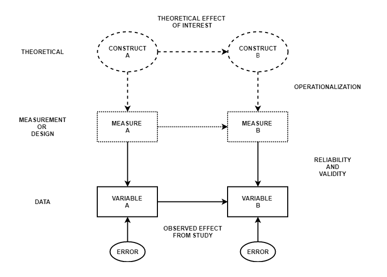

## The many faces of data

- There are a huge amount of ways we can measure things.
  - and our measurement gives rise to data.
  - (this course would be very short if we did not have data)
- Dependent on our measurement choices, data can look quite different.
  - And have different properties.
- There exist a few different schemes for characterising data.

## Types of data

- **Categorical:** Variables with a *discrete* number of response options.
  - These are usually coded as integers.
  - Binary data is a special case with only 2 possible values.

| ID | Hair_colour | Likert_item | Degree |
| --- | --- | --- | --- |
| ID101 | Brown | Strongly Agree | No |
| ID102 | Brown | Agree | No |
| ID103 | Blonde | Agree | Yes |
| ID104 | Blonde | Disagree | Yes |
| ID105 | Black | Strongly Disagree | Yes |

- Example: Hair colour, Likert Scale items, Degree or Not?
- **Categorical:** Variables with a *discrete* number of response options.
  - Binary data is a special case with only 2 possible values.
- **Continuous:** Variables which can take any real number value within the specified range of measurement.

| ID | ReactionTime | Height_cm | Weight_kg |
| --- | --- | --- | --- |
| ID101 | 1.2 | 191.2 | 88.9 |
| ID102 | 0.9 | 180.8 | 76.6 |
| ID103 | 3.2 | 165.3 | 52.0 |
| ID104 | 55.5 | 177.1 | 81.5 |
| ID105 | 2.1 | 201.0 | 105.8 |

- Examples: Height in cm; Weight in kg; Reaction time

## Types of data

- **Categorical**: Variables with a discrete number of response options.
  - Binary data is a special case with only 2 possible values.
- **Continuous**: Variables which can take any real number value within the specified range of measurement.
- **Count**: Variables which can only take non-negative integer values (0,1,2,3 etc.).

## Levels of measurement

- Terms coined by Stevens (1946), and we are still using them!
- 4 levels are general discussed (though also critiqued - see additional reading):
  - Nominal
  - Ordinal
  - Interval
  - Ratio
- With each level, the numeric values we apply hold different meanings, and we are able to do more with the values.

## Nominal data

- Binary or categorical variable where numerical markers share no relationship.
- Here is no meaningful ordering.

| ID | Hair_colour | Hair_values |
| --- | --- | --- |
| ID101 | Brown | 1 |
| ID102 | Brown | 1 |
| ID103 | Blonde | 2 |
| ID104 | Blonde | 2 |
| ID105 | Black | 3 |

- Example: Hair colour
  - 1 = Brown, 2 = Blonde, 3 = Black

## Ordinal data

- Binary or categorical variable where there exists a meaningful way to **rank-order** responses.
- Here X < Y or Y > X statements can be made, but we can not meaningfully quantify the differences.

| ID | Likert_item | Likert_values |
| --- | --- | --- |
| ID101 | Strongly Agree | 5 |
| ID102 | Agree | 4 |
| ID103 | Agree | 4 |
| ID104 | Disagree | 2 |
| ID105 | Strongly Disagree | 1 |

- Example: Likert scale items
  - 1 = Strongly Disagree, 2 = Disagree, 3 = Neither A/D, 4 = Agree, 5 = Strongly Agree

## Interval data

- Variables for which numerical values have meaning.
- There is no true 0 point on an interval scale.
  - But we can consider differences.
  - And the differences have a true 0 point.
- Now it gets harder to talk about psychological examples.
  - Some would consider IQ and other test scores as interval.

## Ratio data

- Variables for which numerical values have meaning.
- Variables have a true 0 point.
  - As a result, it is plausible to multiply and divide ratio variables.
  - We can legitimately talk about double X
- We really have few, if any, ratio measures in psychology.

## Summary

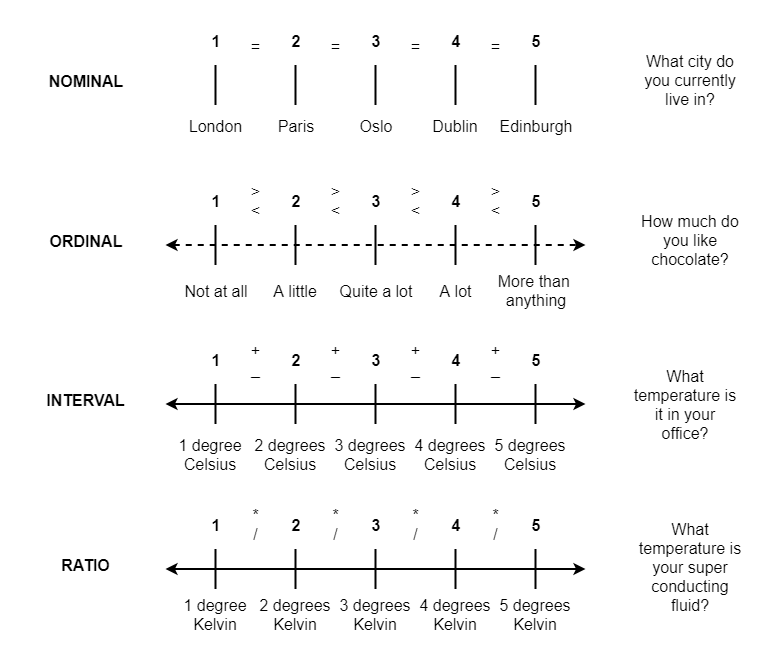

## Data types and R

| R Data Type | Example | Level of Measurement | Data Type |
| --- | --- | --- | --- |
| Character | ID | Nominal | (Categorical) |
| Numeric | Reaction Time | Interval or ratio | Continuous |
| Factor | Hair Colour | Nominal | Categorical |
| Ordered factor | Likert scale | Ordinal | Categorical |

- And a sneak look ahead to how this might look in R.

```
# A tibble: 5 x 4
  ID    Hair_colour Likert_item       ReactionTime
  <chr> <fct>       <fct>                    <dbl>
1 ID101 Brown       Strongly Agree             1.2
2 ID102 Brown       Agree                      0.9
3 ID103 Blonde      Agree                      3.2
4 ID104 Blonde      Disagree                  55.5
5 ID105 Black       Strongly Disagree          2.1
```

## Measurement matters

- Data is information.
- The way we describe, visualize and analyse data depends on the type of data we have.

## Let’s build a class .rmd

- Over the whole course, we are going to build up a single Rmarkdown file.
- We will use to practice, as a class, things you will do in smaller groups in labs.
- We will live code it (so likely make mistakes)
  - This happens all the time, nothing to worry about.
- We will fix problems
- We will explore the data we create

## Tasks for this week…

1. Finish any existing tasks from lab 1.
2. Reading: No compulsory reading for this week.
   - Additional reading on final slide.
3. Quiz 2 (On course guide)
   - Live now.
   - Close Sunday at 17:00

## Recommendations of the week

- Podcast: [*In Our Time* on Gauss](https://www.bbc.co.uk/programmes/b09gbnfj) + [*More of Less*](https://www.bbc.co.uk/programmes/b006qshd)
- Recipe: [Carrot, cougette and sweetcorn fritters](https://www.foodtolovemagazine.co.uk/recipe-articles/courgette-carrot-sweetcorn-fritters)
- Book: [Flatland: A Romance of Many Dimensions, Edwin Abbott](https://www-cambridge-org.ezproxy.is.ed.ac.uk/core/books/flatland/71E876947B2318B1B023975C7EAA5E69)
- Thing to do: Arthur’s Seat
- Coffee/food Place: [Gaia, Leith Walk](http://gaiadeliedinburgh.co.uk/)
  - Best coffee in Edinburgh

## Extra reading

- Michell, J. (1986). Measurement scales and statistics: A clash of paradigms. *Psychological Bulletin, 100*, 398-407. doi: 10.1037/0033-2909.100.3.398
- Stevens, S. S. (1946). On the Theory of Scales of Measurement". *Science, 103*, 677–680. doi:10.1126/science.103.2684.677.